# Democratic Repression: Responding in Kind?

March 30, 2019

## Relevant Repression Findings

- There is a dynamic relationship between dissent and repression (Lichbach 1987, Moore 1998)
- The level of threat a state experiences has a more robust association with repression than democratic-ness (Regan and Henderson 2002)
- As states democratize they tend to violate human rights less (Davenport 1999)
- In general, the “more murder in the middle” hypothesis seems to hold true here (Davenport 2007)

## Theoretical Expectations

Assume:

- Leaders are selfish and seek relection
- Voters are actively aware of threats to public security
- Leaders keep their seats via providing sufficient security
- Democratic leaders behave in a normative context in which repression is not a legitimate policy tool.

Repressive policies are legitimated when the threat to security is sufficiently high

- The public accepts a tradeoff of autonomy for security when threat is sufficiently high (e.g. Davis and Silver 2004)
- Repression for the sake of security provision cannot be incongruent with dissent

## Type of Repression

**Intangible Repression**  
Violating political/civil rights; suspending government services

**Tangible Repression**  
Mobilizing coercive forces, disbanding crowds, harassment, threats, arrests, suspending services, restricting movement (curfew)

**Violent Repression**  
State attacks property/humans with force; including police/military forces

## Expectations

1. Symbolic dissent memory is not associated with repression.
2. As mass expression memory increases, tangible and intangible repression becomes more likely.
3. As political violence memory increases, all repression becomes more likely (intangible, tangible, violent).

\[\sum_{y=1}^{7}\sum_{m=1}^{12} dissent_{ym}^{.9^y}\]

## Analysis

- Random Effects Logit
  - April 1946 - Dec 2012
  - 85 countries
  - Electoral Democracy: 6 of 6 on Lexical Index
  - 20,739 Observations
- Controls:
  - Time polynomial (Carter and Signorino 2010)
  - Civil War
  - Population (total and urban)
  - Logged GDP PC

## Intangible Repression

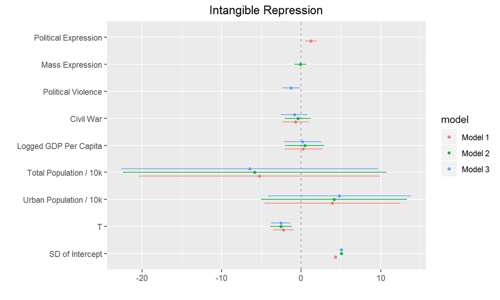

## Tangible Repression

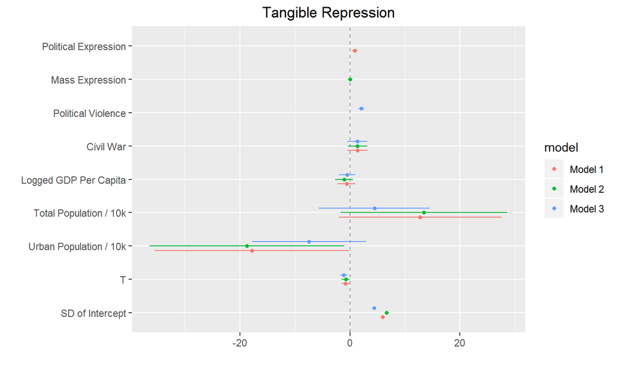

## Violent Repression

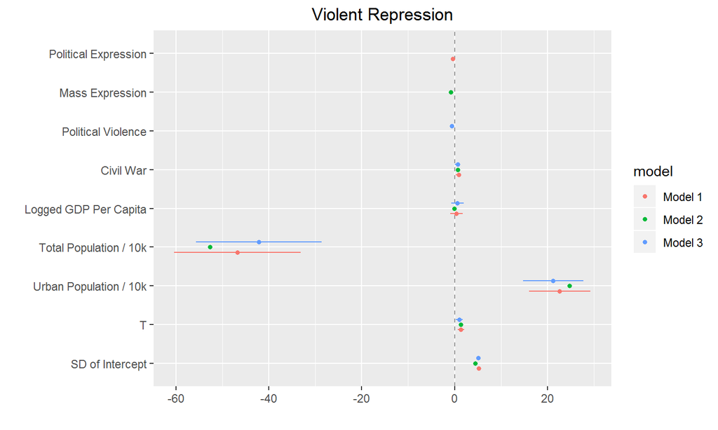

## Conclusions

*Intangible Repression*

- Symbolic dissent increases likelihood
- Political Violence decreases likelihood

*Tangible Repression*

- Symbolic dissent and political violence increase likelihood

*Violent Repression*

- All forms of dissent decrease likelihood

**Democracies tend to avoid violent repression as a response to dissent, and prefer to avoid scrutiny by 'covertly' repressing.**